# Economic and Human Costs of Weather Events in US 1996 - 2011

### Synopsis

In this analysis, we investigate which types of weather events in the United States are most harmful with respect to population health and which have the greatest economic consequences.

The data has two major issues which need to be rectified before further analysis can be carried out. First, the data must be filtered to remove dates prior to 1996 when only 3 events were being cataloged. Second, event types must be prepared such that duplicates can be removed later.

Fatalities and injuries must be investigated separately as a high count in one doesn’t necessarily correlate to a high count in the other. Each table has duplicates removed and the top five positions are filtered.

Crop and property damage values are held in two columns each, one containing a damage amount and the other containing a multiplier, stored as a factor(‘b’ for billion, ‘m’ for million, etc).

These character factors must be converted to numbers and multiplied by the damage amount before they can be summed together to create a dollar total column for both crop and property damage.

Null rows are removed, duplicate rows are merged, the total column is divided by one million (for tidier plotting) and the top five values are arranged in order.

Bar charts are then created to display table information.

### Data Processing

1. Set working directory, load relevant packages and check that directory/files exist before creating/downloading.

```r
setwd("C:/Users/Dangermonger/Documents/GitHub")

library(plyr)
library(dplyr, warn.conflicts=FALSE)
library(ggplot2)

##check that directory exists before creating

ifelse(!dir.exists(file.path("C:/Users/Dangermonger/Documents/GitHub", "./RepData_PeerAssessment2")), +
           dir.create(file.path("C:/Users/Dangermonger/Documents/GitHub", +
                                    "./RepData_PeerAssessment2")), FALSE)
```

```
## [1] FALSE
```

```r
setwd("C:/Users/Dangermonger/Documents/GitHub/Repdata_PeerAssessment2")

##check that files exists in directory before downloading. Use mode="wb" for pdf

if (!file.exists("StormData.csv.bz2")) {
    fileUrl <- "https://d396qusza40orc.cloudfront.net/repdata%2Fdata%2FStormData.csv.bz2"
    download.file(fileUrl, destfile = "./StormData.csv.bz2") ##download file
}

if (!file.exists("repdata-peer2_doc-pd01016005curr.pdf")) {
    fileUrl <- "https://d396qusza40orc.cloudfront.net/repdata%2Fpeer2_doc%2Fpd01016005curr.pdf"
    download.file(fileUrl, destfile = "./repdata-peer2_doc-pd01016005curr.pdf", mode="wb")
}

if (!file.exists("FAQ.pdf")) {
    fileUrl <- "https://d396qusza40orc.cloudfront.net/repdata%2Fpeer2_doc%2FNCDC%20Storm%20Events-FAQ%20Page.pdf"
    download.file(fileUrl, destfile = "./FAQ.pdf", mode="wb")
}
```

2. Storm data can be read directly and is converted to tbl and filtered to remove dates prior to 1996 when only 3 events were being cataloged. Columns of interest are selected, event types are converted to capital letters and a number are approximately or exactly matched and replaced to create the tidy data that will be used in the remainder of the analysis.

```r
##read file directly (don't need to unzip)
stormdata <- read.csv("StormData.csv.bz2")


##convert table to tbl, change date format, filter date, convert EVTYPE to
##capitals, select columns
convertbl <- tbl_df(stormdata) %>%
    mutate(BGN_DATE = as.Date(BGN_DATE, format = "%m/%d/%Y")) %>%
    filter(BGN_DATE >= "1996-01-01") %>%
    mutate(EVTYPE = toupper(as.character(EVTYPE))) %>%
    select(EVTYPE, FATALITIES, INJURIES, PROPDMGEXP, PROPDMG, +
               CROPDMGEXP, CROPDMG)

##approximately or exactly match EVTYPE values

idx <- agrep(pattern = "FLOOD", convertbl$EVTYPE, max.distance = 1)
convertbl$EVTYPE[idx] <- "FLOOD"

idx <- agrep(pattern = "HAIL", convertbl$EVTYPE, max.distance = 1)
convertbl$EVTYPE[idx] <- "HAIL"

idx <- grep(pattern = "(STORM SURGE|STORM SURGE/TIDE)", convertbl$EVTYPE)
convertbl$EVTYPE[idx] <- "STORM SURGE"

idx <- grep(pattern = "(HURRICANE|TYPHOON)", convertbl$EVTYPE)
convertbl$EVTYPE[idx] <- "HURRICANE"

idx <- grep(pattern = "(HEAT|EXCESSIVE HEAT)", convertbl$EVTYPE)
convertbl$EVTYPE[idx] <- "HEAT"
```

3. Fatalities/injuries are investigated by selecting the event type, fatalities and injuries columns and removing rows where fatalities and injuries amount to zero.

```r
harmtbl <- convertbl %>%
    select(EVTYPE, INJURIES, FATALITIES) %>%
    filter(FATALITIES & INJURIES > 0) ##remove rows where damage = 0
```

4. This data frame is then transformed twice to create top five tables for both injuries and fatalities with each data frame split by event type and a columnwise function applied to sum/remove duplicate values. Each table is selected by event type and fatalities or injuries, arranged in descending order and filtered by the top five positions.

```r
fatrem <-  harmtbl %>%
    ddply("EVTYPE", numcolwise(sum)) %>% ##remove duplicates
    select(EVTYPE, FATALITIES) %>%
    arrange(desc(FATALITIES)) %>% ##order by fatalities
    top_n(5)
injrem <-  harmtbl %>%
    ddply("EVTYPE", numcolwise(sum)) %>% ##remove duplicates
    select(EVTYPE, INJURIES) %>%
    arrange(desc(INJURIES)) %>% ##order by injuries
    top_n(5)
```

5. To sum crop and property damage it is first necessary to convert a factor column containing number abbreviations (‘b’ for billion, ‘m’ for million, etc) to exponent values.

```r
unique(convertbl$PROPDMGEXP) ##find unique cost values for property damage
```

```
## [1] K   M B 0
## Levels:  - ? + 0 1 2 3 4 5 6 7 8 B h H K m M
```

```r
unique(convertbl$CROPDMGEXP) ##find unique cost values for crop damage
```

```
## [1] K   M B
## Levels:  ? 0 2 B k K m M
```

```r
##substitute characters for numerical values

convertbl$PROPDMGEXP <- gsub("B", 10^9, convertbl$PROPDMGEXP)
convertbl$PROPDMGEXP <- gsub("M", 10^6, convertbl$PROPDMGEXP)
convertbl$PROPDMGEXP <- gsub("m", 10^6, convertbl$PROPDMGEXP)
convertbl$PROPDMGEXP <- gsub("K", 10^3, convertbl$PROPDMGEXP)
convertbl$PROPDMGEXP <- gsub("H", 10^2, convertbl$PROPDMGEXP)
convertbl$PROPDMGEXP <- gsub("h", 10^2, convertbl$PROPDMGEXP)

convertbl$CROPDMGEXP <- gsub("B", 10^9, convertbl$CROPDMGEXP)
convertbl$CROPDMGEXP <- gsub("m", 10^6, convertbl$CROPDMGEXP)
convertbl$CROPDMGEXP <- gsub("M", 10^6, convertbl$CROPDMGEXP)
convertbl$CROPDMGEXP <- gsub("k", 10^3, convertbl$CROPDMGEXP)
convertbl$CROPDMGEXP <- gsub("K", 10^3, convertbl$CROPDMGEXP)
```

6. A table is then created where the exponent column for both crops and property is multiplied by the damage column and a combined DamageTotal column is created containing the row sums of the multiplied columns. The relevant columns are selected and null rows are removed.

```r
##Multiply PROPDMG by PROPDMGEX and CROPDMG by CROPDMGEX before summing. Remove
##null rows.

multbl <- convertbl %>%
    mutate(PropDamageTotal = PROPDMG * as.numeric(PROPDMGEXP)) %>%
    mutate(CropDamageTotal = CROPDMG * as.numeric(CROPDMGEXP)) %>%
    mutate(DamageTotal = rowSums(.[8:9], na.rm = TRUE)) %>%
    select(EVTYPE, DamageTotal) %>%
    filter(DamageTotal > 0) ##remove rows where damage = 0
```

7. Duplicate rows are merged, the total column is divided by one million and the top five values are arranged in order.

```r
duprem <-  multbl %>%
    ddply("EVTYPE", numcolwise(sum)) %>% ##remove duplicates
    mutate(DamageTotal = DamageTotal/10^6) %>%
    arrange(desc(DamageTotal)) %>% ##order by damage amount
    top_n(5)
```

### Results

#### 1. Across the United States, which types of events (as indicated in the EVTYPE variable) are most harmful with respect to population health?

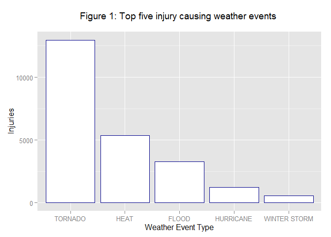

```r
ggplot(data=injrem,
       aes(x = reorder(EVTYPE, -INJURIES), y = INJURIES)) +
    labs(title="Figure 1: Top five injury causing weather events \n") +
    labs(x="Weather Event Type", y="Injuries") +
    geom_bar(binwidth=1, fill="white", colour="darkblue", stat = "identity")
```

Above we see the top five injury causing weather events in the United States. It can be seen that Tornados are by far the most dangerous weather event, causing more injuries than the next four events combined.

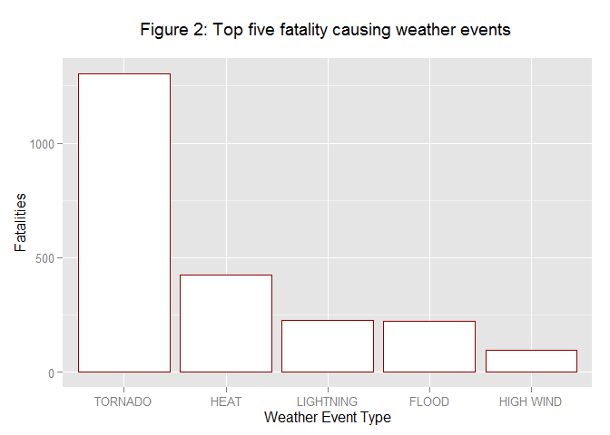

```r
ggplot(data=fatrem,
    aes(x = reorder(EVTYPE, -FATALITIES), y = FATALITIES)) +
    labs(title="Figure 2: Top five fatality causing weather events \n") +
    labs(x="Weather Event Type", y="Fatalities") +
    geom_bar(binwidth=1, fill="white", colour="darkred", stat = "identity")
```

We can see from the graph above that fatalities correlate quite closely with injuries, however, we now see Lightning in the top five. This perhaps illustrates the fact that lightning is more likely to cause death than simple injury.

#### 2. Across the United States, which types of events have the greatest economic consequences?

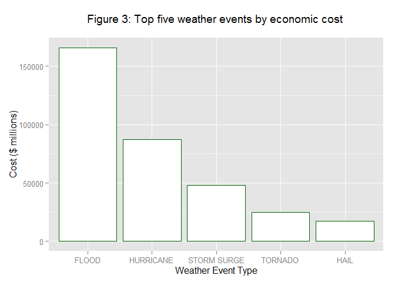

```r
ggplot(data=duprem,
    aes(x = reorder(EVTYPE, -DamageTotal), y = DamageTotal)) +
    labs(title="Figure 3: Top five weather events by economic cost \n") +
    labs(x="Weather Event Type", y="Cost ($ millions)") +
    geom_bar(binwidth=1, fill="white", colour="darkgreen", stat = "identity")
```

The most damaging events economically emphaise the difference between the violence of the event and the extent of its reach. Flooding and hurricanes commonly cover vast areas while tornados, while devastating, are more likely to be localised.